# Tercer Parcial Modelaje

16 noviembre, 2021

# Estimar el $R_0$

## Conceptos básicos

El $R_0$ es un concepto de epidemiología, tiene una interpretación asociada, es el **número reproductivo básico**, lo que significa es que dado un individuo infectado, cuántos individuos en promedio puede infectar.

El hecho de que tenga el subíndice *0*, significa que esto ocurre si no hubiera intervenciones (farmacológico, vacunación, aislamiento, cuarentena) entonces así es como se comportaría la enfermedad, libremente. Al incio de la epidemia, es así como se comporta. El $R_0$ es al incio de la epidemia y sin medidas de control.

Algunas medidas de control son como aislamiento, cuarntena, farmacológica, vacunación. Cuando estas intervienen en la dinámica de la enfermedad, se modifica dicha dinámica. Eñ $R_0$ es natural del patógeno/cepa. Hay cosas que dependen del $R_0$ y otras que no.

En el modelo **SIS**, el $R_0$ es $\frac{\beta}{\gamma}$. Algunas medidas de control como el aislamiento y cuarentena afectan al parámetro $\beta$. Las vacunas impactan en $\beta$ y las medidas farmacológicas al $\gamma$.

El $R_0$ solo se establece cuando no existen medidas de control. Las medidas impactan en los parámetros que definen al $R_0$. Ya sea que reducen el número de suceptibles o de los infectados, alguno de los dos compartimentos.

Por ejemplo, con las vacunas, pueden hacer que la transmisión sea menos efectiva, o incluso cortar la cadena de transimisión, que haga la $\beta = 0$ o $\beta \approx 0$, aunque no sean 100% efectivas, tienen un rango donde reducen la $\beta$ y por ende, el $R_0$.

- Inmunidad de rebaño: $1 - \frac{1}{R_0}$

Las medidas de control, tratan de reducir el valor de $R_0$. Ya que se sabe que si $R_0 < 1$ el punto de equilibrio estable es el free-disease, en cambio, para un $R_0 > 1$, el punto de equilibrio estable es el endémico. Con un $R_0 > 1$ y sin medidas de control, nos vemos al punto endémico. La idea es implementar las medidas de control para empujar al sistema al otro punto de equilibrio, por distintos métodos.

Ténicamente, el $R_0$ solo se usa al inicio de la enfermedad y sin medidas de control. Cuando se implementan medidas de control, de habla de un $R_t$, que tiene que ver con el número reroductivo básico de la enfermedad al tiempo **t**. Con las medidas de control se pretende que el $R_t < R_0$ y además que sea menor que 1, para que sea efectivo.

Podemos calcular el $R_t$ de distintos lugares asociados a las medidas de control. El $R_0$ es asociado a la variante, y es general. El $R_t$ puede ser distinto en distintos lados, y se puede calcular a partir de los datos.

Los pasos son:

1. Estimar el $R_0$
2. Medidas de control
3. Obtener datos
4. Estimar el $R_t$

Escencialmente, es una bifurcación dependiente del $R_t$, cambiando los parámetros.

## Estimación

Basado en el modelo **SIS** sin demografía

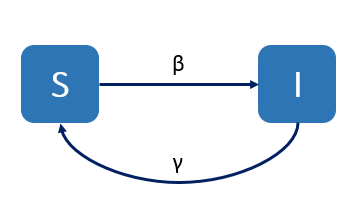

Modelo SIS

Se asume que la fración de la población total es 1 y la población se conserva. Los suceptibles varian con respecto al tiempo, los infectados varían con respecto al tiempo, pero la suma se conserva. Son los mismos individuos.

$$1 = S + I$$

Las ecuaciones del modelo son:

$$\begin{array}{l}
\dot S = - \beta SI + \gamma I \\
\dot I = \beta SI - \gamma I
\end{array}$$

Con este sistema, se puede reducir a una sola dimensión. Podemos escoger una ecuación para expresar una variable en términos de la otra.

$$\dot I = \beta (1-I)I - \gamma I$$

Considerando que se está estimado el $R_0$ al inicio de la epidemia, y que hay muy pocos infectados, se puede decir que: $I \approx 0$. Lo que significa que, la cantidad de infectados es muy muy pequeña, comparando un caso contra la población de un país, **AL INICIO**. Comparado con la fracción total de la población, $1 \gg I$, lo que significa que $1-I \approx 1$. Por ejemplo, en México, si solo hubiera un solo infectado, $I = \frac{1}{127,000,000} = 1*10^{-8}$. Como esto ocurre al incio, no quiere decir que sean válidad siempre. Eso sifgnifica que podemos reescribir:

$$\begin{array}{l}
\dot I \approx \beta (1)I - \gamma I \\
\dot I \approx \beta I - \gamma I \\
\dot I \approx I ( \beta - \gamma)
\end{array}$$

Entonces, al incio, esta es la dinámica. Como $(\beta - \gamma)$ es unca constante, la solución de esta ecuación diferencial es:

$$I(t) = I_0 e^{(\beta - \gamma) t}$$

Esta exponencial puede tener tres comportamientos, dependiendo del valor de los parámetros, dado un número de $I_0$ :

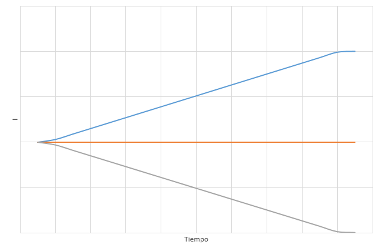

Exponencial

La condición:
$$\begin{array}{l}
\beta - \gamma > 0 \\
\beta > \gamma \\
\frac{\beta}{\gamma} > 1 \\
\\
\text{Para el modelo, el } R_0 \text{ es:}
\frac{\beta}{\gamma}
\\
R_0 > 1 \\
\end{array}$$

Qué tan rápido va a crecer?? Dependerá del valor de la diferencia de $\beta - \gamma$.

Esta es la justificaicón por la cual, las epidemias al inicio, se comportan de manera exponencial, cuando el $R_0 > 1$.

Una vez con los datos, al incio, se observaría, dado un número de infectados y antes de que se tomen medidas de control, se tendría que observar un crecimiento exponecial.

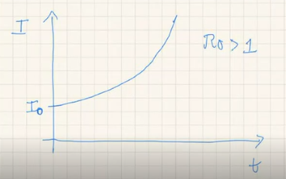

Exponencial

Los datos, los casos, deberían ajustarse más o menos, a una forma exponencial, $I(t) = I_0 e^{(\beta - \gamma) t}$. Una vez se toman medidas de control o con inmunidad adquirida, el número de infectados deja de ser exponencial, llega a un pico y luego disminuye. Pero al inicio es donde se puede estimar el $R_0$.

Podemos escribir
$$I(t) = I_0 e^{(\beta - \gamma) t}$$

Y sabemos que
$$R_0 = \frac{\beta}{\gamma}$$

Al despejar $\beta$ nos queda
$$\beta = R_0 \gamma$$

Entonces, se puede reescribir, para involucrar en la constante al $R_0$
$$I(t) = I_0 e^{(R_0 \gamma - \gamma) t} \\
= I(t) = I_0 e^{\gamma(R_0 - 1)t}$$

Con esta ultima expresión, es más claro. Cuando se comporta como una exponencial creciente, $R_0 > 1$.

Entonces, si se tienen los datos, y al inicio, se comportan de manera exponencial, para calcular el $R_0$, se tiene que los casos están dados por $I(t)$, y si se convierte a expresiones logarítimicas, se obtiene que:
$$I(t) = log (I_0) + \gamma(R_0 - 1)t$$
Teniendo a $log (I_0)$ como una constante: B, **+** la constante m, por t:
$$I=B+mt$$
Se obtiene al ecuación de la recta. Cuando se transforman los datos de manera logarítmicca, se obtiene una recta, y la pendiente ayuda a estimar el valor de $R_0$.

Un análisis que es útil para estimar definitivamente el valor de $R_0$ es una regresión lineal, para poder inferir los parámetros la línea recta e inferir directamente el $R_0$.

El momento en que se hace el corte para el cálulo, es cuando la pendiente cambia, ya que esta aproximación del $R_0$ es al incio, bajo el supuesto de que el número de individuos infectados es pequeño y no hay medidas de control. No hay un criterio de oro en el cuál se haga el corte de los datos, va a haber un momento cuando ya no crezca de forma exponencial. Se deberían probar distintos ajustes en distintos intervalos de datos, el valor de $R^2$ de la regresión, nos indica qué tanto se ajustan los datos a la exponencial, y detectar en qué momento ya no es exponencial.

# Uso de Tidyverse

La libreria *Tidyverse* es un escosistema para trabajar con datos.

```r
library(tidyverse)
```

Para trabajar con esta librería, se usan los datos de anotación del [genoma de E.coli](https://www.ncbi.nlm.nih.gov/genome/browse/#!/proteins/167/161521%7CEscherichia%20coli%20str.%20K-12%20substr.%20MG1655/)

```r
annotation_e_coli_k_12 <- read.csv("proteins_167_161521.csv")
head(annotation_e_coli_k_12)
```

```
##       X.Name   Accession Start Stop Strand GeneID Locus Locus.tag
## 1 chromosome NC_000913.3   190  255      + 944742  thrL     b0001
## 2 chromosome NC_000913.3   337 2799      + 945803  thrA     b0002
## 3 chromosome NC_000913.3  2801 3733      + 947498  thrB     b0003
## 4 chromosome NC_000913.3  3734 5020      + 945198  thrC     b0004
## 5 chromosome NC_000913.3  5234 5530      + 944747  yaaX     b0005
## 6 chromosome NC_000913.3  5683 6459      - 944749  yaaA     b0006
##   Protein.product Length                                      Protein.Name
## 1     NP_414542.1     21                         thr operon leader peptide
## 2     NP_414543.1    820 fused aspartate kinase/homoserine dehydrogenase 1
## 3     NP_414544.1    310                                 homoserine kinase
## 4     NP_414545.1    428                                threonine synthase
## 5     NP_414546.1     98            DUF2502 domain-containing protein YaaX
## 6     NP_414547.1    258           peroxide stress resistance protein YaaA
```

```r
glimpse(annotation_e_coli_k_12)
```

```
## Rows: 4,285
## Columns: 11
## $ X.Name          <chr> "chromosome", "chromosome", "chromosome", "chromosome"~
## $ Accession       <chr> "NC_000913.3", "NC_000913.3", "NC_000913.3", "NC_00091~
## $ Start           <int> 190, 337, 2801, 3734, 5234, 5683, 6529, 8238, 9306, 99~
## $ Stop            <int> 255, 2799, 3733, 5020, 5530, 6459, 7959, 9191, 9893, 1~
## $ Strand          <chr> "+", "+", "+", "+", "+", "-", "-", "+", "+", "-", "-",~
## $ GeneID          <int> 944742, 945803, 947498, 945198, 944747, 944749, 944745~
## $ Locus           <chr> "thrL", "thrA", "thrB", "thrC", "yaaX", "yaaA", "yaaJ"~
## $ Locus.tag       <chr> "b0001", "b0002", "b0003", "b0004", "b0005", "b0006", ~
## $ Protein.product <chr> "NP_414542.1", "NP_414543.1", "NP_414544.1", "NP_41454~
## $ Length          <int> 21, 820, 310, 428, 98, 258, 476, 317, 195, 188, 237, 1~
## $ Protein.Name    <chr> "thr operon leader peptide", "fused aspartate kinase/h~
```

```
annotation_e_coli_k_12 <- read_csv("proteins_167_161521.csv")
```

Con la función `read_csv` da más información.  
La función `glimpse()` es como darle un vistazo rápido al objeto de la base de datos. Sirve para tablas de datos muy grandes. Da igual información de la abse de datos.

## Verbos

### Filter

Se filtran renglones que cumplan una cierta condición. Las condicones pueden ser complejas para filtrar los renglones que cumplan esas condicones.

Por ejemplo, podemos filtrar la base de datos para obtener solamente los genomas de cadena positiva de la base de datos.

```r
positivos <- filter(annotation_e_coli_k_12, Strand == "+")
glimpse(annotation_e_coli_k_12)
```

```
## Rows: 4,285
## Columns: 11
## $ X.Name          <chr> "chromosome", "chromosome", "chromosome", "chromosome"~
## $ Accession       <chr> "NC_000913.3", "NC_000913.3", "NC_000913.3", "NC_00091~
## $ Start           <int> 190, 337, 2801, 3734, 5234, 5683, 6529, 8238, 9306, 99~
## $ Stop            <int> 255, 2799, 3733, 5020, 5530, 6459, 7959, 9191, 9893, 1~
## $ Strand          <chr> "+", "+", "+", "+", "+", "-", "-", "+", "+", "-", "-",~
## $ GeneID          <int> 944742, 945803, 947498, 945198, 944747, 944749, 944745~
## $ Locus           <chr> "thrL", "thrA", "thrB", "thrC", "yaaX", "yaaA", "yaaJ"~
## $ Locus.tag       <chr> "b0001", "b0002", "b0003", "b0004", "b0005", "b0006", ~
## $ Protein.product <chr> "NP_414542.1", "NP_414543.1", "NP_414544.1", "NP_41454~
## $ Length          <int> 21, 820, 310, 428, 98, 258, 476, 317, 195, 188, 237, 1~
## $ Protein.Name    <chr> "thr operon leader peptide", "fused aspartate kinase/h~
```

```r
head(positivos)
```

```
##       X.Name   Accession Start Stop Strand GeneID Locus Locus.tag
## 1 chromosome NC_000913.3   190  255      + 944742  thrL     b0001
## 2 chromosome NC_000913.3   337 2799      + 945803  thrA     b0002
## 3 chromosome NC_000913.3  2801 3733      + 947498  thrB     b0003
## 4 chromosome NC_000913.3  3734 5020      + 945198  thrC     b0004
## 5 chromosome NC_000913.3  5234 5530      + 944747  yaaX     b0005
## 6 chromosome NC_000913.3  8238 9191      + 944748  talB     b0008
##   Protein.product Length                                      Protein.Name
## 1     NP_414542.1     21                         thr operon leader peptide
## 2     NP_414543.1    820 fused aspartate kinase/homoserine dehydrogenase 1
## 3     NP_414544.1    310                                 homoserine kinase
## 4     NP_414545.1    428                                threonine synthase
## 5     NP_414546.1     98            DUF2502 domain-containing protein YaaX
## 6     NP_414549.1    317                                   transaldolase B
```

Por ejemplo, para filtrar a las proteínas entre 50 y 75 aminoácidos

```r
head(filter(annotation_e_coli_k_12, Length >= 50 & Length <= 75))
```

```
##       X.Name   Accession  Start   Stop Strand   GeneID Locus Locus.tag
## 1 chromosome NC_000913.3  16751  16960      -   944756  mokC     b0018
## 2 chromosome NC_000913.3  16751  16903      -  2847744  hokC     b4412
## 3 chromosome NC_000913.3  21181  21399      +   949128  yaaY     b0024
## 4 chromosome NC_000913.3  59121  59279      + 38094933  yabQ     b0057
## 5 chromosome NC_000913.3 111649 111846      -   945630  yacG     b0101
## 6 chromosome NC_000913.3 213925 214125      -  1450233  yaeP     b4406
##   Protein.product Length                           Protein.Name
## 1     NP_414559.1     69                regulatory protein MokC
## 2     YP_025292.1     50                           protein HokC
## 3     NP_414565.1     72 DUF2575 domain-containing protein YaaY
## 4  YP_009518735.1     52                           protein YabQ
## 5     NP_414643.1     65              DNA gyrase inhibitor YacG
## 6     YP_026160.1     66            UPF0253 family protein YaeP
```

```r
nega_100 <- filter(annotation_e_coli_k_12, Strand == "-" & Length < 100)
glimpse(nega_100)
```

```
## Rows: 256
## Columns: 11
## $ X.Name          <chr> "chromosome", "chromosome", "chromosome", "chromosome"~
## $ Accession       <chr> "NC_000913.3", "NC_000913.3", "NC_000913.3", "NC_00091~
## $ Start           <int> 16751, 16751, 20233, 20815, 83622, 85467, 111649, 2136~
## $ Stop            <int> 16960, 16903, 20508, 21078, 83708, 85511, 111846, 2139~
## $ Strand          <chr> "-", "-", "-", "-", "-", "-", "-", "-", "-", "-", "-",~
## $ GeneID          <int> 944756, 2847744, 948449, 944759, 946072, 38094934, 945~
## $ Locus           <chr> "mokC", "hokC", "insA1", "rpsT", "leuL", "yabR", "yacG~
## $ Locus.tag       <chr> "b0018", "b4412", "b0022", "b0023", "b0075", "b4726", ~
## $ Protein.product <chr> "NP_414559.1", "YP_025292.1", "NP_414563.1", "NP_41456~
## $ Length          <int> 69, 50, 91, 87, 28, 14, 65, 84, 66, 92, 86, 91, 73, 79~
## $ Protein.Name    <chr> "regulatory protein MokC", "protein HokC", "IS1 protei~
```

```r
exac100 <- filter(annotation_e_coli_k_12, Strand == "-" & Length == 100)
exac100["Accession"]
```

```
##     Accession
## 1 NC_000913.3
## 2 NC_000913.3
```

3. ¿Cuántas proteínas son mayores a la longitud promedio y cuántas están en la cadena positiva y cuántas en la negativa?

```r
positivos <- filter(annotation_e_coli_k_12, Strand == "+" & Length>mean(Length))
negativos <- filter(annotation_e_coli_k_12, Strand == "-" & Length>mean(Length))

glimpse(positivos)
```

```
## Rows: 877
## Columns: 11
## $ X.Name          <chr> "chromosome", "chromosome", "chromosome", "chromosome"~
## $ Accession       <chr> "NC_000913.3", "NC_000913.3", "NC_000913.3", "NC_00091~
## $ Start           <int> 337, 2801, 3734, 8238, 12163, 14168, 15445, 17489, 214~
## $ Stop            <int> 2799, 3733, 5020, 9191, 14079, 15298, 16557, 18655, 22~
## $ Strand          <chr> "+", "+", "+", "+", "+", "+", "+", "+", "+", "+", "+",~
## $ GeneID          <int> 945803, 947498, 945198, 944748, 944750, 944753, 944754~
## $ Locus           <chr> "thrA", "thrB", "thrC", "talB", "dnaK", "dnaJ", "insL1~
## $ Locus.tag       <chr> "b0002", "b0003", "b0004", "b0008", "b0014", "b0015", ~
## $ Protein.product <chr> "NP_414543.1", "NP_414544.1", "NP_414545.1", "NP_41454~
## $ Length          <int> 820, 310, 428, 317, 638, 376, 370, 388, 313, 938, 316,~
## $ Protein.Name    <chr> "fused aspartate kinase/homoserine dehydrogenase 1", "~
```

```r
glimpse(negativos)
```

```
## Rows: 928
## Columns: 11
## $ X.Name          <chr> "chromosome", "chromosome", "chromosome", "chromosome"~
## $ Accession       <chr> "NC_000913.3", "NC_000913.3", "NC_000913.3", "NC_00091~
## $ Start           <int> 6529, 36271, 37898, 39244, 40417, 52427, 53416, 54755,~
## $ Stop            <int> 7959, 37824, 39115, 40386, 41931, 53416, 54702, 57109,~
## $ Strand          <chr> "-", "-", "-", "-", "-", "-", "-", "-", "-", "-", "-",~
## $ GeneID          <int> 944745, 944886, 948997, 949064, 944765, 944919, 944812~
## $ Locus           <chr> "yaaJ", "caiC", "caiB", "caiA", "caiT", "pdxA", "surA"~
## $ Locus.tag       <chr> "b0007", "b0037", "b0038", "b0039", "b0040", "b0052", ~
## $ Protein.product <chr> "NP_414548.1", "NP_414579.4", "NP_414580.1", "NP_41458~
## $ Length          <int> 476, 517, 405, 380, 504, 329, 428, 784, 968, 783, 500,~
## $ Protein.Name    <chr> "putative transporter YaaJ", "carnitine--CoA ligase", ~
```

### Seleccionar

Permite seleccionar columnas

```r
head(select(annotation_e_coli_k_12, Strand))
```

```
##   Strand
## 1      +
## 2      +
## 3      +
## 4      +
## 5      +
## 6      -
```

Puedo seleccionar más de una columna, con una notación tipo vector

```r
head(select(annotation_e_coli_k_12, c(Accession, Strand)))
```

```
##     Accession Strand
## 1 NC_000913.3      +
## 2 NC_000913.3      +
## 3 NC_000913.3      +
## 4 NC_000913.3      +
## 5 NC_000913.3      +
## 6 NC_000913.3      -
```

Se pueden quitar columnas específicas, por ejemplo, si de las 11 columnas queremos quitar una, es decir, deja todas las columnas excepto tal.

```r
head(select(annotation_e_coli_k_12 ,-Strand))
```

```
##       X.Name   Accession Start Stop GeneID Locus Locus.tag Protein.product
## 1 chromosome NC_000913.3   190  255 944742  thrL     b0001     NP_414542.1
## 2 chromosome NC_000913.3   337 2799 945803  thrA     b0002     NP_414543.1
## 3 chromosome NC_000913.3  2801 3733 947498  thrB     b0003     NP_414544.1
## 4 chromosome NC_000913.3  3734 5020 945198  thrC     b0004     NP_414545.1
## 5 chromosome NC_000913.3  5234 5530 944747  yaaX     b0005     NP_414546.1
## 6 chromosome NC_000913.3  5683 6459 944749  yaaA     b0006     NP_414547.1
##   Length                                      Protein.Name
## 1     21                         thr operon leader peptide
## 2    820 fused aspartate kinase/homoserine dehydrogenase 1
## 3    310                                 homoserine kinase
## 4    428                                threonine synthase
## 5     98            DUF2502 domain-containing protein YaaX
## 6    258           peroxide stress resistance protein YaaA
```

También se pueden seleccionar columnas que cumplan con un cierto patrón. No es sensible a mayúsculas y minúsculas.

```r
head(select(annotation_e_coli_k_12, starts_with("S")))
```

```
##   Start Stop Strand
## 1   190  255      +
## 2   337 2799      +
## 3  2801 3733      +
## 4  3734 5020      +
## 5  5234 5530      +
## 6  5683 6459      -
```

```r
head(select(annotation_e_coli_k_12, contains("x")))
```

```
##       X.Name
## 1 chromosome
## 2 chromosome
## 3 chromosome
## 4 chromosome
## 5 chromosome
## 6 chromosome
```

```r
head(select(annotation_e_coli_k_12, ends_with("h")))
```

```
##   Length
## 1     21
## 2    820
## 3    310
## 4    428
## 5     98
## 6    258
```

1. Seleecionar todas las columnas de tipo chr y todas las de tipo dbl

```r
glimpse(annotation_e_coli_k_12 %>% select(is.double, is.character))
```

```
## Rows: 4,285
## Columns: 7
## $ X.Name          <chr> "chromosome", "chromosome", "chromosome", "chromosome"~
## $ Accession       <chr> "NC_000913.3", "NC_000913.3", "NC_000913.3", "NC_00091~
## $ Strand          <chr> "+", "+", "+", "+", "+", "-", "-", "+", "+", "-", "-",~
## $ Locus           <chr> "thrL", "thrA", "thrB", "thrC", "yaaX", "yaaA", "yaaJ"~
## $ Locus.tag       <chr> "b0001", "b0002", "b0003", "b0004", "b0005", "b0006", ~
## $ Protein.product <chr> "NP_414542.1", "NP_414543.1", "NP_414544.1", "NP_41454~
## $ Protein.Name    <chr> "thr operon leader peptide", "fused aspartate kinase/h~
```

2. Quitar todas las columnas con el nombre del gen y/o proteína

```r
head(annotation_e_coli_k_12 %>% select( - is.character))
```

```
##   Start Stop GeneID Length
## 1   190  255 944742     21
## 2   337 2799 945803    820
## 3  2801 3733 947498    310
## 4  3734 5020 945198    428
## 5  5234 5530 944747     98
## 6  5683 6459 944749    258
```

3. Dejar una tabla con su nombre preferido del gen o proteína y que sólo contenga esa información, más el strand y el tamaño.

```r
head(select(annotation_e_coli_k_12, c(Accession, Strand, Length)))
```

```
##     Accession Strand Length
## 1 NC_000913.3      +     21
## 2 NC_000913.3      +    820
## 3 NC_000913.3      +    310
## 4 NC_000913.3      +    428
## 5 NC_000913.3      +     98
## 6 NC_000913.3      -    258
```

### Ordenar

Se usa la función arrange()

Puede ordenar, de acuerdo a las columnas.

```r
head(arrange(annotation_e_coli_k_12, Length))
```

```
##       X.Name   Accession   Start    Stop Strand   GeneID Locus Locus.tag
## 1 chromosome NC_000913.3 1079120 1079146      + 38094948  ymdG     b4737
## 2 chromosome NC_000913.3 3737177 3737203      - 63925657  baxL     b4794
## 3 chromosome NC_000913.3 2483729 2483758      + 63925643  evgL     b4781
## 4 chromosome NC_000913.3 3573679 3573708      - 63925652  yhgP     b4789
## 5 chromosome NC_000913.3  754658  754690      - 63925628  ybgV     b4768
## 6 chromosome NC_000913.3 2347350 2347385      - 63925641  yoaM     b4779
##   Protein.product Length                                   Protein.Name
## 1  YP_009518762.2      8                                   protein YmdG
## 2  YP_010051207.1      8 putative translational regulatory protein BaxL
## 3  YP_010051191.1      9                                   protein EvgL
## 4  YP_010051202.1      9                                   protein YhgP
## 5  YP_010051177.1     10                                   protein YbgV
## 6  YP_010051189.1     11                                   protein YoaM
```

```r
head(arrange(annotation_e_coli_k_12, Accession))
```

```
##       X.Name   Accession Start Stop Strand GeneID Locus Locus.tag
## 1 chromosome NC_000913.3   190  255      + 944742  thrL     b0001
## 2 chromosome NC_000913.3   337 2799      + 945803  thrA     b0002
## 3 chromosome NC_000913.3  2801 3733      + 947498  thrB     b0003
## 4 chromosome NC_000913.3  3734 5020      + 945198  thrC     b0004
## 5 chromosome NC_000913.3  5234 5530      + 944747  yaaX     b0005
## 6 chromosome NC_000913.3  5683 6459      - 944749  yaaA     b0006
##   Protein.product Length                                      Protein.Name
## 1     NP_414542.1     21                         thr operon leader peptide
## 2     NP_414543.1    820 fused aspartate kinase/homoserine dehydrogenase 1
## 3     NP_414544.1    310                                 homoserine kinase
## 4     NP_414545.1    428                                threonine synthase
## 5     NP_414546.1     98            DUF2502 domain-containing protein YaaX
## 6     NP_414547.1    258           peroxide stress resistance protein YaaA
```

```r
head(arrange(annotation_e_coli_k_12, Start))
```

```
##       X.Name   Accession Start Stop Strand GeneID Locus Locus.tag
## 1 chromosome NC_000913.3   190  255      + 944742  thrL     b0001
## 2 chromosome NC_000913.3   337 2799      + 945803  thrA     b0002
## 3 chromosome NC_000913.3  2801 3733      + 947498  thrB     b0003
## 4 chromosome NC_000913.3  3734 5020      + 945198  thrC     b0004
## 5 chromosome NC_000913.3  5234 5530      + 944747  yaaX     b0005
## 6 chromosome NC_000913.3  5683 6459      - 944749  yaaA     b0006
##   Protein.product Length                                      Protein.Name
## 1     NP_414542.1     21                         thr operon leader peptide
## 2     NP_414543.1    820 fused aspartate kinase/homoserine dehydrogenase 1
## 3     NP_414544.1    310                                 homoserine kinase
## 4     NP_414545.1    428                                threonine synthase
## 5     NP_414546.1     98            DUF2502 domain-containing protein YaaX
## 6     NP_414547.1    258           peroxide stress resistance protein YaaA
```

### Crear nuevas variables

Por ejemplo, obtener el tamaño del gen, no de la proteína, restanto el Stop menos el Start.

Se usa la función mutate()

```r
tam_n <- mutate(annotation_e_coli_k_12, tamano_nucleotidos = Stop - Start)
head(mutate(tam_n, Bigger_than_nc_mean=ifelse(tamano_nucleotidos>mean(tamano_nucleotidos),T,F)))
```

```
##       X.Name   Accession Start Stop Strand GeneID Locus Locus.tag
## 1 chromosome NC_000913.3   190  255      + 944742  thrL     b0001
## 2 chromosome NC_000913.3   337 2799      + 945803  thrA     b0002
## 3 chromosome NC_000913.3  2801 3733      + 947498  thrB     b0003
## 4 chromosome NC_000913.3  3734 5020      + 945198  thrC     b0004
## 5 chromosome NC_000913.3  5234 5530      + 944747  yaaX     b0005
## 6 chromosome NC_000913.3  5683 6459      - 944749  yaaA     b0006
##   Protein.product Length                                      Protein.Name
## 1     NP_414542.1     21                         thr operon leader peptide
## 2     NP_414543.1    820 fused aspartate kinase/homoserine dehydrogenase 1
## 3     NP_414544.1    310                                 homoserine kinase
## 4     NP_414545.1    428                                threonine synthase
## 5     NP_414546.1     98            DUF2502 domain-containing protein YaaX
## 6     NP_414547.1    258           peroxide stress resistance protein YaaA
##   tamano_nucleotidos Bigger_than_nc_mean
## 1                 65               FALSE
## 2               2462                TRUE
## 3                932                TRUE
## 4               1286                TRUE
## 5                296               FALSE
## 6                776               FALSE
```

# Datos de COVID

Se hizo la tarea con los datos de COVID

# Modelo de dos cepas

- Hay dos cepas circulantes de una enfermedad
- Se describe un modelo SIR
- Hay inmunidad cruzada completa

Para este modelo se considera:

- una tasa de infección asociada a la cepa
- una tasa de mortalidad asociada a la infección
- la tasa de recuperación depende de la cepa

## Esquema de compartimentos

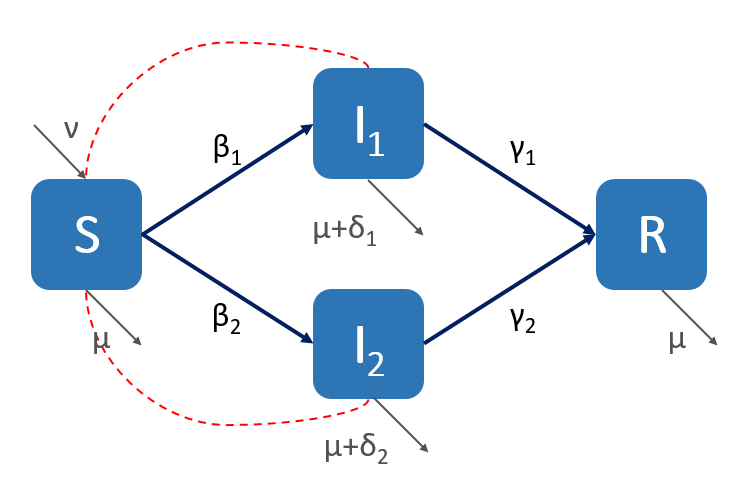

Diagrama

## Ecuaciones

$$\begin{array}{l}
\dot S = \nu - \beta_1 S I_1 - \beta_2 S I_2 - \mu S \\
\dot I_1 = \beta_1 S I_1 - \gamma_1 I_1 - (\mu + \delta_1) I_1 \\
\dot I_2 = \beta_2 S I_2 - \gamma_2 I_2 - (\mu + \delta_2) I_2 \\
\dot R = \gamma_1 I_1 + \gamma_2 I_2 - \mu R
\end{array}$$

## Parámetros

- $\nu$ : tasa de nacimientos
- $\beta_1$ : tasa de infección de la cepa 1
- $\beta_2$ : tasa de infección de la cepa 2
- $\mu$ : tasa de mortalidad poblacional
- $\delta_1$ : tasa de mortalidad asociada a la infección de la cepa 1
- $\delta_2$ : tasa de mortalidad asociada a la infección de la cepa 2
- $\gamma_1$ : tasa de recuperación de la cepa 1
- $\gamma_2$ : tasa de recuperación de la cepa 2

## Describir el $R_0$

$$R_0 = \frac{\beta_1}{\gamma_1 + (\mu + \delta_1)} +
\frac{\beta_2}{\gamma_2 + (\mu + \delta_2)}$$

También se puede definir un $R_0$ para cada cepa

- Para la cepa 1:

$$R_0^1 = \frac{\beta_1}{\gamma_1 + (\mu + \delta_1)}$$

- Para la cepa 2:

$$R_0^2 = \frac{\beta_2}{\gamma_2 + (\mu + \delta_2)}$$

Esencialmente, al calcular los valores de $R_0$ vamos a obtener tres posibles resultados:

- Que el $R_0^1 > R_0^2$
- Que el $R_0^1 = R_0^2$
- Que el $R_0^1 < R_0^2$

### Evolución competitiva de la virulencia.

Cuando hay distintas cepas que compiten por un mismo recurso limitante, en este caso el hospedero, se da el fenómeno de exclusión competitiva. Lo que determina que una de las cepas excluya a la otra, es el valor de $R_0$. Aquella cepa que tenga el valor de $R_0$ grande, va a excluir a la otra y va a dominar. Esto se observa con la variante delta de SARS-Cov-2.

Que el sistema se colapse hacia alguna de las dos cepas dependen del valor del $R_0$, cuando se tiene un recurso limitante idéntico.

### Incrementar el valor de $R_0$

Hay dos formas en las que el valor del $R_0$ se puede incrementar, en términos de los parámetros.

1. Hacer muy grande el numerador.  
   Es decir, que, para este caso, $\beta_1 > \gamma_1 + (\mu + \delta_1)$. Es decir, si el denominador se queda fijo y el numerador aumenta. Significaría que la tasa de infección aumenta, y por ende el $R_0$.
2. Hacer muy pequeño el denominador.  
   Para este mismo caso, si $\beta_1 < \gamma_1 + (\mu + \delta_1)$. Es decir, se el numerador se queda fijo, y el denominador disminuye, Significaría que disminuyen, la tasa de recuperación mas la tasa de mortalidad asociada a la infección.

Para que haya exclusión competitiva de dos cepas, tienen que aumentar su $R_0$, y para esto, hay dos caminos, que aumente la tasa de infección o que reduzca la tasa de recuperació o de mortalidad.

## Resolverlo numéricamente

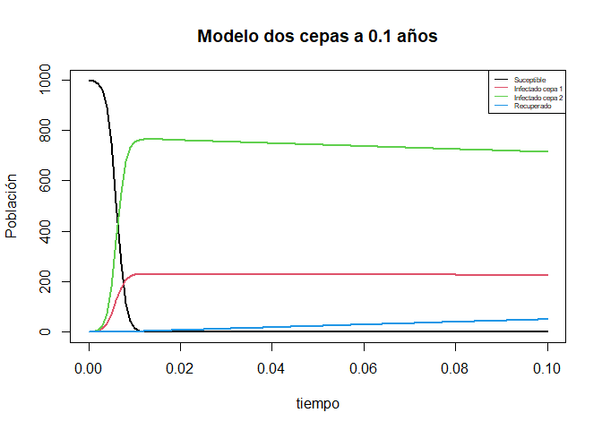

```r
library(deSolve)

two_cepas <- function (t, state, parameters){
  with(as.list(c(state, parameters)), {

    N <- S + I1 + I2 + R
    dS <- nu*N - beta1*S*I1 - beta2*S*I2 - mu*S
    dI1 <- beta1*S*I1 - gamma1*I1 - (mu+delta1)*I1
    dI2 <- beta2*S*I2 - gamma2*I2 - (mu+delta2)*I2
    dR <- gamma1*I1 + gamma2*I2 - mu*R

    list(c(dS, dI1, dI2, dR))

  })
}

parameters <- c(nu=0.1, beta1=0.9, beta2=1.1, mu=0.1, gamma1=0.1,
                gamma2=0.7, delta1=0.101, delta2=0.105)
state <- c(S= 998, I1= 1, I2=1, R=0)
t <- seq(0,0.1,0.001)

out <- ode(state, t, two_cepas, parameters)

matplot(out[,1], out[,2:5], type ="l", xlab = "tiempo", ylab = "Población", main = "Modelo dos cepas a 0.1 años", lwd = 2, lty = 1)
legend("topright", c("Suceptible", "Infectado cepa 1", "Infectado cepa 2", "Recuperado"), col = 1:5, lty = 1, cex = 0.5)
```

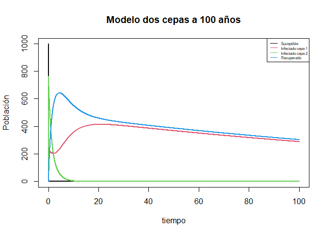

```r
parameters <- c(nu=0.1, beta1=0.9, beta2=1.1, mu=0.1, gamma1=0.1,
                gamma2=0.7, delta1=0.01, delta2=0.05)
state <- c(S= 998, I1= 1, I2=1, R=0)
t <- seq(0,100,0.001)

out <- ode(state, t, two_cepas, parameters)

matplot(out[,1], out[,2:5], type ="l", xlab = "tiempo", ylab = "Población", main = "Modelo dos cepas a 100 años", lwd = 2, lty = 1)
legend("topright", c("Suceptible", "Infectado cepa 1", "Infectado cepa 2", "Recuperado"), col = 1:5, lty = 1, cex = 0.5)
```

# Modelo de distintos patógenos que comparten un host

## Supuestos

Para este modelo se considera:

Es un modelo SIR con un hospedero que es compartido. Solo es un patógeno que puede infectar a dos posibles hospederos.

## Diagrama por compartimentos

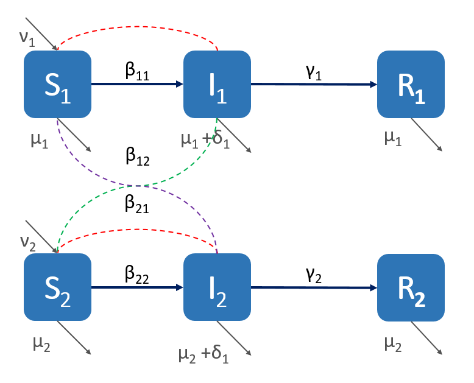

Diagrama

## Ecuaciones

$$\begin{array}{l}
\dot S_1 = \nu_1 - \beta_{11}S_1I_1 - \beta_{12}S_1I_2 - \mu_1S_1 \\
\dot I_1 = \beta_{11}S_1I_1 + \beta_{12}S_1I_2 - (\mu_1+\delta_1)I_1 - \gamma_1I_1 \\
\dot R_1 = \gamma_1I_1 - \mu_1R_1 \\
\\
\dot S_2 = \nu_2 - \beta_{22}S_2I_2 - \beta_{21}S_2I_1 - \mu_2S_2 \\
\dot I_2 = \beta_{22}S_2I_2 + \beta_{21}S_2I_1 - (\mu_2+\delta_2)I_2 - \gamma_2I_2 \\
\dot R_2 = \gamma_2I_2 - \mu_2R_2
\end{array}$$

## Parámetros

- Para el host 1:
  - $\nu_1$ : tasa de nacimiento del host 1
  - $\beta_{11}$ : tasa de infección por contacto de un suceptible del host 1 con un infectado del host 1
  - $\beta_{12}$ : tasa de infección por contacto de un suceptible del host 1 con un infectado del host 2
  - $\mu_1$ : tasa de mortalidad poblacional del host 1
  - $\delta_1$ : tasa de mortalidad asociada a la infección en el host 1
  - $\gamma_1$ : tasa de recuperación del host 1
- Para el host 2:
  - $\nu_2$ : tasa de nacimiento del host 2
  - $\beta_{22}$ : tasa de infección por contacto de un suceptible del host 2 con un infectado del host 2
  - $\beta_{21}$ : tasa de infección por contacto de un suceptible del host 2 con un infectado del host 1
  - $\mu_2$ : tasa de mortalidad poblacional del host 2
  - $\delta_2$ : tasa de mortalidad asociada a la infección en el host 2
  - $\gamma_2$ : tasa de recuperación del host 2

## Determinarlo numéricamente

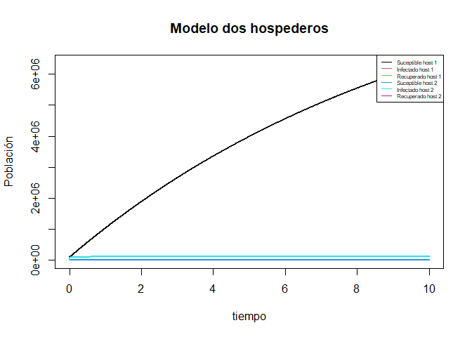

```r
#Parametros
## Host1
nu1 <- 10
beta11 <- 0
beta12 <- 0
mu1 <- 0.1
delta1 <- 0
gamma1 <- 0.5
N1 <- 100000
## Host2
nu2 <- 1
beta22 <- 0.9
beta21 <- 1.2
mu2 <- 0.2
delta2 <- 0.09
gamma2 <- 0.5
N2 <- 100000


library(deSolve)


two_host <- function (t, x, params){

  S1 <- x[1] #Suceptibles Host 1
  I1 <- x[2] #Infectados Host 1
  R1 <- x[3] #Recuperados Host 1

  S2 <- x[4] #Suceptibles Hot 2
  I2 <- x[5] #Infectados Host 2
  R2 <- x[6] #Recuperados Host2


  with(as.list(params), {

    # Host 1
    dS1 <- nu1*N1 - beta11*S1*I1 - beta12*S1*I2 - mu1*S1
    dI1 <- beta11*S1*I1 + beta12*S1*I2 - (mu1+delta1)*I1 - gamma1*I1
    dR1 <- gamma1*I1 - mu1*R1

    # Host 2
    dS2 <- nu2*N2 - beta22*S2*I2 - beta21*S2*I1 - mu2*S2
    dI2 <- beta22*S2*I2 + beta21*S2*I1 - (mu2+delta2)*I2 - gamma2*I2
    dR2 <- gamma2*I2 - mu2*R2

    dx <- c(dS1, dI1, dR1, dS2, dI2, dR2)
    list(dx)

  })
}

#Tiempo
times <- seq(0, 10 , by = 0.001)

#Especificar parametros

params <- c(
  #Host1
  nu1       = nu1   ,
  beta11    = beta11,
  beta12    = beta12,
  mu1       = mu1   ,
  delta1    = delta1,
  gamma1    = gamma1,
  N1        = N1    ,
  #Host2
  nu2       = nu2   ,
  beta22    = beta22,
  beta21    = beta21,
  mu2       = mu2   ,
  delta2    = delta2,
  gamma2    = gamma2,
  N2        = N2
)

#Condiciones iniciales del sistema

xstart <- c(S1 = N1 - 1 ,
            I1 = 1      ,
            R1 = 0      ,
            S2 = N2 - 1 ,
            I2 = 1      ,
            R2 = 0)

#Resolver las ecuaciones

out <- as.data.frame(ode(y     = xstart   ,
                         times = times    ,
                         func  = two_host ,
                         parms = params))

#Graficar

matplot(out[,1], out[,2:6], type ="l", xlab = "tiempo", ylab = "Población", main = "Modelo dos hospederos", lwd = 2, lty = 1)
legend("topright", c("Suceptible host 1",
                     "Infectado host 1" ,
                     "Recuperado host 1",
                     "Suceptible host 2",
                     "Infectado host 2" ,
                     "Recuperado host 2"),
       col = 1:6, lty = 1, cex = 0.5)
```

# Modelo de transimisión por vectores

## Supuestos

- No hay transmisión entre humanos o vectores
- Consideramos a los mosquitos como vectores
- Modelo SI para los vectores. Una razón puede ser por su tiempo de vida, es muy corto. No pueden recuperarse.
- Modelo SIR para humanos
- Se considera el modelo de malaria

**Supuestos agregados por mi**

- La $\beta_{hm} > \beta_{mh}$
- Las $\mu_h < \mu_m$
- La $\nu_h < \nu_m$
- Hay una tasa de mortalidad asociada a la infección. Los mosquitos no porque por su tiempo de vida, no es significativo a la infección.
- La tasa de nacimientos aumenta el número de suceptbiles, por ende, modifica el $R_0$

## Diagrama por compartimentos

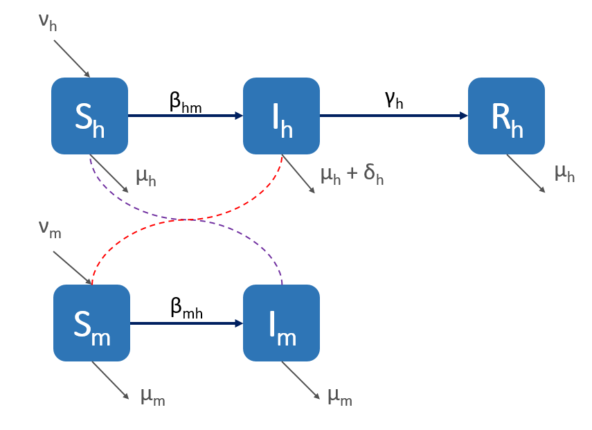

Diagrama

## Ecuaciones

$$\begin{array}{l}
\dot S_h = \nu_h - \beta_{hm}S_hI_m - \mu_hS_h \\
\dot I_h = \beta_{hm}S_hI_m - \gamma_hI_h - (\mu_h+\delta_h)I_h \\
\dot R_h = \gamma_hI_h - \mu_hR_h \\
\\
\dot S_m = \nu_m - \beta_{mh}S_mI_h - \mu_mS_m \\
\dot I_m = \beta_{mh}S_mI_h - \mu_mI_m
\end{array}$$

## Parámetros

- $\nu_h$ : tasa de nacimientos de humanos
- $\beta_{hm}$ : tasa de infección por la picadura de un mosquito infectado a un humano suceptible
- $\mu_h$ : tasa de mortalidad poblacional de los humanos
- $\delta_h$ : tasa de mortalidad asociada a la infección en humanos
- $\gamma_h$ : tasa de recuperación de humanos
- $\nu_m$ : tasa de nacimientos de mosquitos
- $\beta_{mh}$ : tasa de infección por la picadura de un mosquito suceptible a un humano infectado
- $\mu_m$ : tasa de mortalidad de los mosquitos

## Posible $R_0$

- $R_0$ de los humanos:
  $$R_0^h = \frac{\nu_h \beta_{hm} }{\gamma_h + (\mu_h + \delta_h)}$$
- $R_0$ de los mosquitos:
  $$R_0^m = \frac{\nu_m \beta_{mh}}{\mu_m}$$
- $R_0$ general del sistema:
  $$R_0 = \frac{\nu_h \beta_{hm} }{\gamma_h + (\mu_h + \delta_h)} +
  \frac{\nu_m \beta_{mh}}{\mu_m}$$

## Resolverlo numéricamente

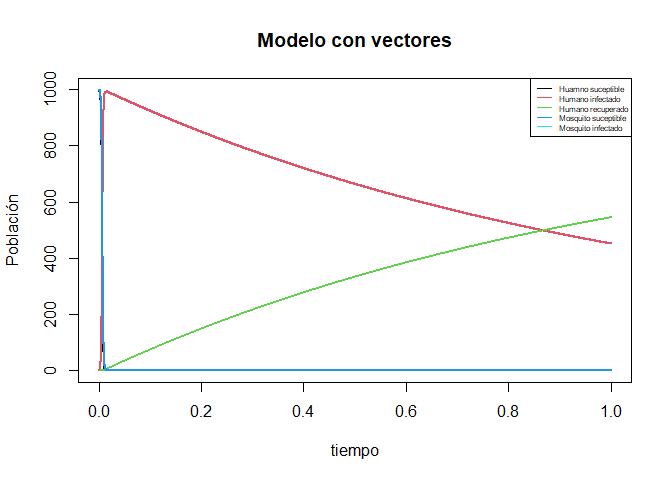

```r
#Parametros
nuh <- 0.1
betahm <- 1.1
muh <- 0.1
deltah <- 0.005
gammah <- 0.85
Nh <- 1000
num <- 0.8
betamh <- 0.9
mum <- 0.5
Nm <- 1000


library(deSolve)


inf_vectores <- function (t, x, params){

  Sh <- x[1] #Suceptibles humanos
  Ih <- x[2] #Infectados humanos
  Rh <- x[3] #Recuperados humanos

  Sm <- x[4] #Suceptibles mosquitos
  Im <- x[5] #Infectados mosquitos


  with(as.list(params), {

    dSh <- nuh*Nh - betahm*Sh*Im - muh*Sh
    dIh <- betahm*Sh*Im - gammah*Ih - (muh+deltah)*Ih
    dRh <- gammah*Ih - muh*Rh

    dSm <- num*Nm - betamh*Sm*Ih - mum*Sm
    dIm <- betamh*Sm*Ih - mum*Im

    dx <- c(dSh, dIh, dRh, dSm, dIm)
    list(dx)

  })
}

#Tiempo
times <- seq(0, 1 , by = 0.00001)

#Especificar parametros

params <- c(
  nuh    = nuh   ,
  betahm = betahm,
  muh    = muh   ,
  deltah = deltah,
  gammah = gammah,
  Nh     = Nh    ,
  num    = num   ,
  betamh = betamh,
  mum    = mum   ,
  Nm     = Nm
)

#Condiciones iniciales del sistema

xstart <- c(Sh = Nh - 1 ,
            Ih = 1      ,
            Rh = 0      ,
            Sm = Nm - 1 ,
            Im = 1      )

#Resolver las ecuaciones

out <- as.data.frame(ode(y     = xstart       ,
                         times = times        ,
                         func  = inf_vectores ,
                         parms = params))

#Graficar

matplot(out[,1], out[,2:5], type ="l", xlab = "tiempo", ylab = "Población", main = "Modelo con vectores", lwd = 2, lty = 1)
legend("topright", c("Huamno suceptible"  ,
                     "Humano infectado"   ,
                     "Humano recuperado"  ,
                     "Mosquito suceptible",
                     "Mosquito infectado"),
       col = 1:5, lty = 1, cex = 0.5)
```

# Modelo del Zika